# Data Visualization Using ggplot

Ilyas Ustun

In this lesson, we will learn how to create very nice plots using the ggplot library. Although creating plots using base R might be easier, to create nice looking plots ggplot is a better approach.

ggplot is present within the greater realm of `tidyverse` - which is library of packages including `dplyr`.

```r
# install.packages("tidyverse")
library(tidyverse)
```

Reading in the “auto-mpg.csv” data using tidyverse. The equivalent using base R would be `read.csv()`.

```r
df = read_csv("auto-mpg.csv")
str(df)
```

```
## spec_tbl_df [398 × 9] (S3: spec_tbl_df/tbl_df/tbl/data.frame)
##  $ mpg         : num [1:398] 18 15 18 16 17 15 14 14 14 15 ...
##  $ cylinders   : num [1:398] 8 8 8 8 8 8 8 8 8 8 ...
##  $ displacement: num [1:398] 307 350 318 304 302 429 454 440 455 390 ...
##  $ horsepower  : num [1:398] 130 165 150 150 140 198 220 215 225 190 ...
##  $ weight      : num [1:398] 3504 3693 3436 3433 3449 ...
##  $ acceleration: num [1:398] 12 11.5 11 12 10.5 10 9 8.5 10 8.5 ...
##  $ model_year  : num [1:398] 70 70 70 70 70 70 70 70 70 70 ...
##  $ origin      : num [1:398] 1 1 1 1 1 1 1 1 1 1 ...
##  $ car_name    : chr [1:398] "chevrolet chevelle malibu" "buick skylark 320" "plymouth satellite" "amc rebel sst" ...
##  - attr(*, "spec")=
##   .. cols(
##   ..   mpg = col_double(),
##   ..   cylinders = col_double(),
##   ..   displacement = col_double(),
##   ..   horsepower = col_double(),
##   ..   weight = col_double(),
##   ..   acceleration = col_double(),
##   ..   model_year = col_double(),
##   ..   origin = col_double(),
##   ..   car_name = col_character()
##   .. )
##  - attr(*, "problems")=<externalptr>
```

```r
glimpse(df)
```

```
## Rows: 398
## Columns: 9
## $ mpg          <dbl> 18, 15, 18, 16, 17, 15, 14, 14, 14, 15, 15, 14, 15, 14, 2…
## $ cylinders    <dbl> 8, 8, 8, 8, 8, 8, 8, 8, 8, 8, 8, 8, 8, 8, 4, 6, 6, 6, 4, …
## $ displacement <dbl> 307, 350, 318, 304, 302, 429, 454, 440, 455, 390, 383, 34…
## $ horsepower   <dbl> 130, 165, 150, 150, 140, 198, 220, 215, 225, 190, 170, 16…
## $ weight       <dbl> 3504, 3693, 3436, 3433, 3449, 4341, 4354, 4312, 4425, 385…
## $ acceleration <dbl> 12.0, 11.5, 11.0, 12.0, 10.5, 10.0, 9.0, 8.5, 10.0, 8.5, …
## $ model_year   <dbl> 70, 70, 70, 70, 70, 70, 70, 70, 70, 70, 70, 70, 70, 70, 7…
## $ origin       <dbl> 1, 1, 1, 1, 1, 1, 1, 1, 1, 1, 1, 1, 1, 1, 3, 1, 1, 1, 3, …
## $ car_name     <chr> "chevrolet chevelle malibu", "buick skylark 320", "plymou…
```

```r
head(df)
```

```
## # A tibble: 6 × 9
##     mpg cylinders displacement horsepower weight accele…¹ model…² origin car_n…³
##   <dbl>     <dbl>        <dbl>      <dbl>  <dbl>    <dbl>   <dbl>  <dbl> <chr>
## 1    18         8          307        130   3504     12        70      1 chevro…
## 2    15         8          350        165   3693     11.5      70      1 buick …
## 3    18         8          318        150   3436     11        70      1 plymou…
## 4    16         8          304        150   3433     12        70      1 amc re…
## 5    17         8          302        140   3449     10.5      70      1 ford t…
## 6    15         8          429        198   4341     10        70      1 ford g…
## # … with abbreviated variable names ¹acceleration, ²model_year, ³car_name
```

## Scatter plot

Plot of mpg vs horsepower:

using base R:

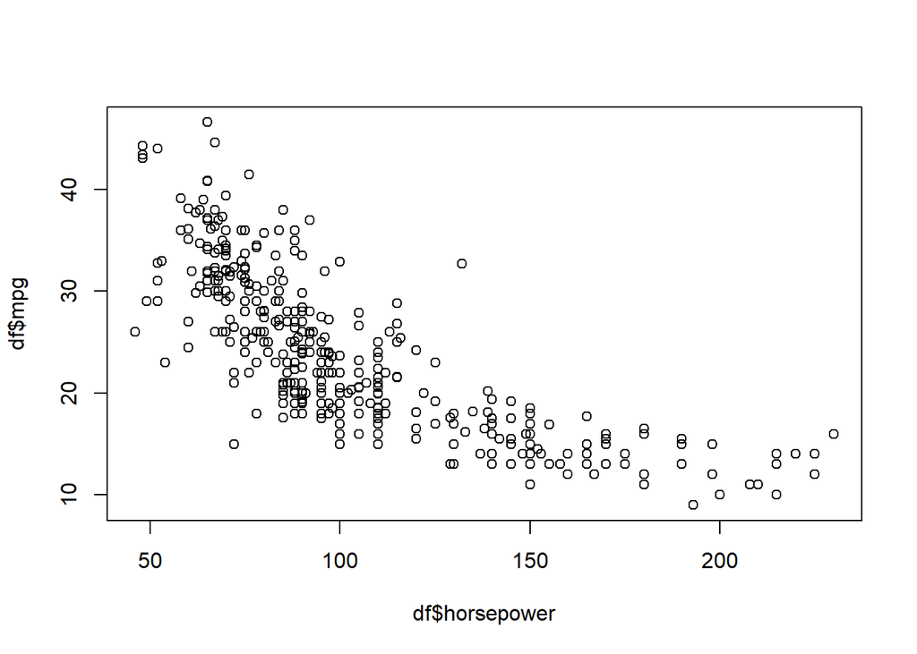

```r
plot(df$horsepower, df$mpg)
```

using ggplot:

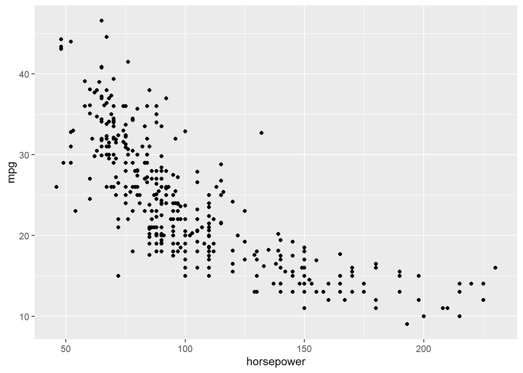

```r
ggplot(df, aes(x=horsepower, y=mpg)) + geom_point()
```

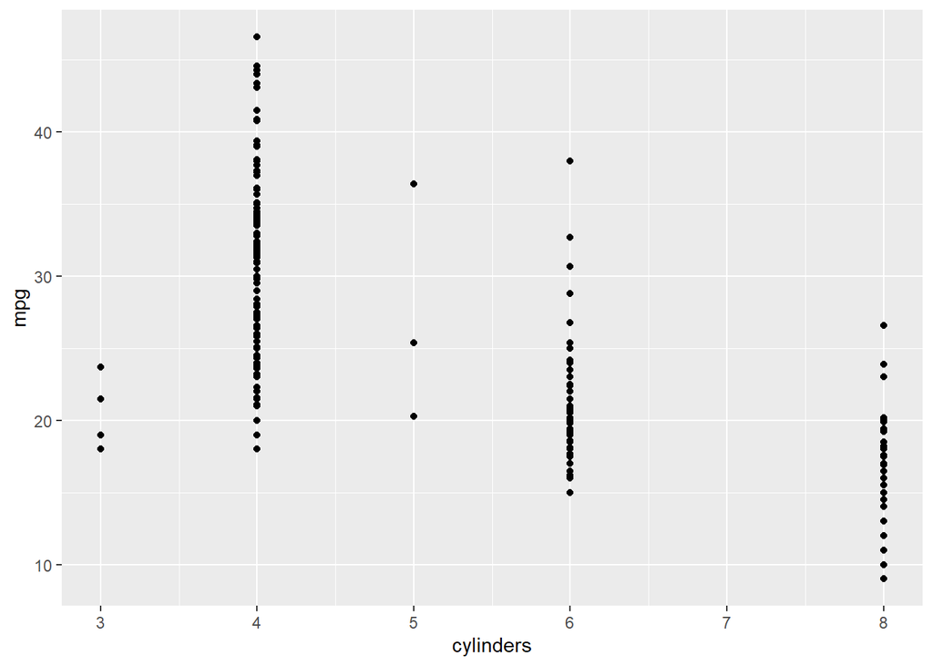

```r
ggplot(df, aes(x=cylinders, y=mpg)) + geom_point()
```

*jitter* will add randomness to the points in the scatter plot

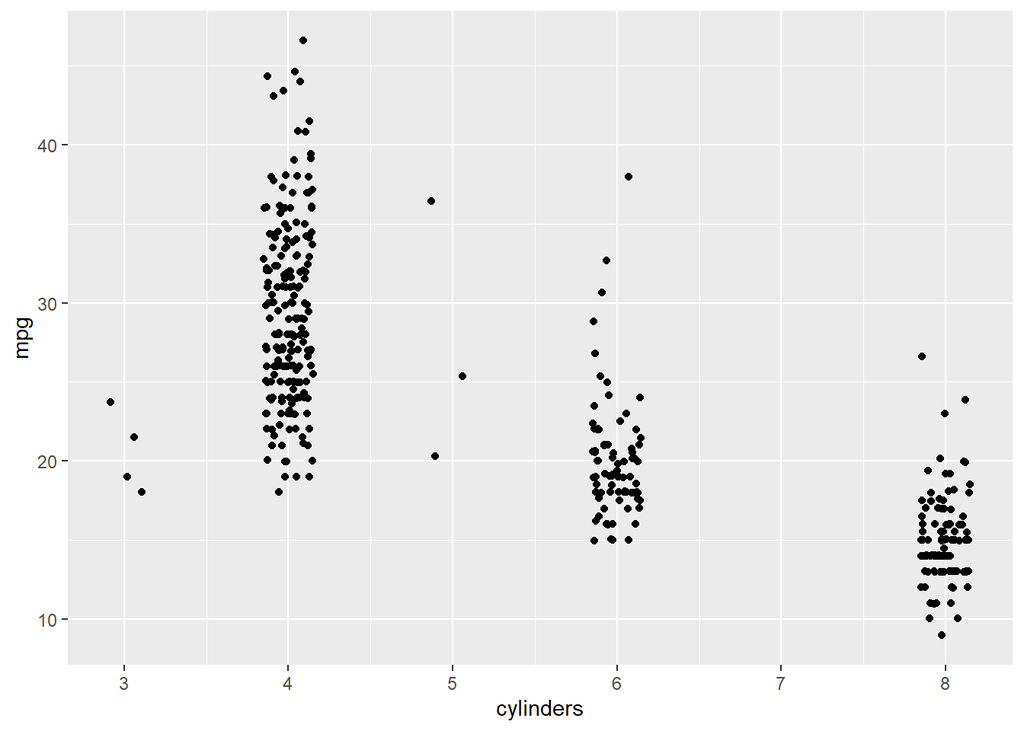

```r
ggplot(df, aes(x=cylinders, y=mpg)) + geom_jitter(width = 0.15)
```

Color the points based on cylinders variable:

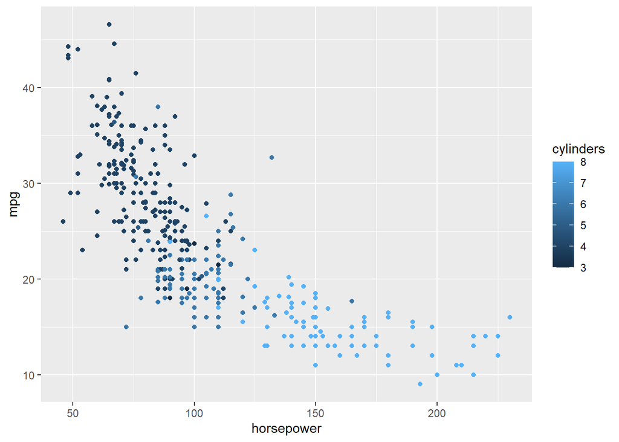

```r
ggplot(df, aes(x=horsepower, y=mpg, color=cylinders)) + geom_point()
```

Because cylinders is a numeric variable, the points are colored in a continuous sequential manner.

We can convert `cylinders` variable to categorical type by using `as.factor()`. Here the change is made within ggplot, so the change does not affect the dataset.

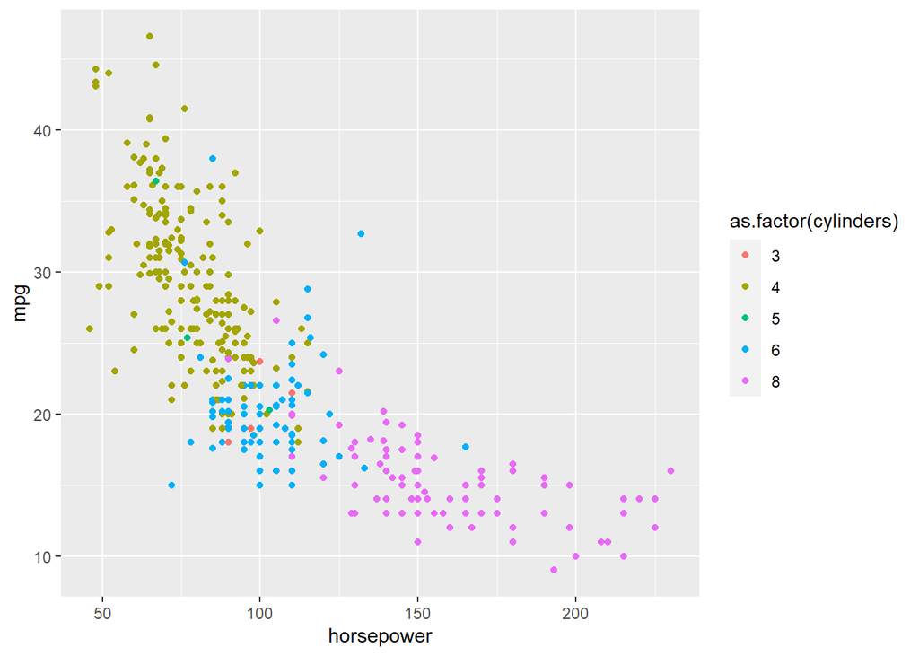

```r
ggplot(df, aes(x=horsepower, y=mpg, color=as.factor(cylinders))) + geom_point()
```

### Converting cylinders to categorical type

Let’s convert the cylinders variable to categorical type:

```r
df = df %>% mutate(cyl_cat = as.factor(cylinders))

df$cyl_cat
```

```
##   [1] 8 8 8 8 8 8 8 8 8 8 8 8 8 8 4 6 6 6 4 4 4 4 4 4 6 8 8 8 8 4 4 4 4 6 6 6 6
##  [38] 6 8 8 8 8 8 8 8 6 4 6 6 4 4 4 4 4 4 4 4 4 4 4 4 4 8 8 8 8 8 8 8 8 8 3 8 8
##  [75] 8 8 4 4 4 4 4 4 4 4 4 8 8 8 8 8 8 8 8 8 8 8 8 6 6 6 6 6 4 8 8 8 8 6 4 4 4
## [112] 3 4 6 4 8 8 4 4 4 4 8 4 6 8 6 6 6 6 4 4 4 4 6 6 6 8 8 8 8 8 4 4 4 4 4 4 4
## [149] 4 4 4 4 6 6 6 6 8 8 8 8 6 6 6 6 6 8 8 4 4 6 4 4 4 4 6 4 6 4 4 4 4 4 4 4 4
## [186] 4 4 8 8 8 8 6 6 6 6 4 4 4 4 6 6 6 6 4 4 4 4 4 8 4 6 6 8 8 8 8 4 4 4 4 4 8
## [223] 8 8 8 6 6 6 6 8 8 8 8 4 4 4 4 4 4 4 4 6 4 3 4 4 4 4 4 8 8 8 6 6 6 4 6 6 6
## [260] 6 6 6 8 6 8 8 4 4 4 4 4 4 4 4 5 6 4 6 4 4 6 6 4 6 6 8 8 8 8 8 8 8 8 4 4 4
## [297] 4 5 8 4 8 4 4 4 4 4 6 6 4 4 4 4 4 4 4 4 6 4 4 4 4 4 4 4 4 4 4 5 4 4 4 4 4
## [334] 6 3 4 4 4 4 4 4 6 4 4 4 4 4 4 4 4 4 4 4 4 4 4 4 4 4 4 6 6 6 6 8 6 6 4 4 4
## [371] 4 4 4 4 4 4 4 4 4 4 4 4 4 4 4 4 6 6 4 6 4 4 4 4 4 4 4 4
## Levels: 3 4 5 6 8
```

```r
str(df)
```

```
## tibble [398 × 10] (S3: tbl_df/tbl/data.frame)
##  $ mpg         : num [1:398] 18 15 18 16 17 15 14 14 14 15 ...
##  $ cylinders   : num [1:398] 8 8 8 8 8 8 8 8 8 8 ...
##  $ displacement: num [1:398] 307 350 318 304 302 429 454 440 455 390 ...
##  $ horsepower  : num [1:398] 130 165 150 150 140 198 220 215 225 190 ...
##  $ weight      : num [1:398] 3504 3693 3436 3433 3449 ...
##  $ acceleration: num [1:398] 12 11.5 11 12 10.5 10 9 8.5 10 8.5 ...
##  $ model_year  : num [1:398] 70 70 70 70 70 70 70 70 70 70 ...
##  $ origin      : num [1:398] 1 1 1 1 1 1 1 1 1 1 ...
##  $ car_name    : chr [1:398] "chevrolet chevelle malibu" "buick skylark 320" "plymouth satellite" "amc rebel sst" ...
##  $ cyl_cat     : Factor w/ 5 levels "3","4","5","6",..: 5 5 5 5 5 5 5 5 5 5 ...
```

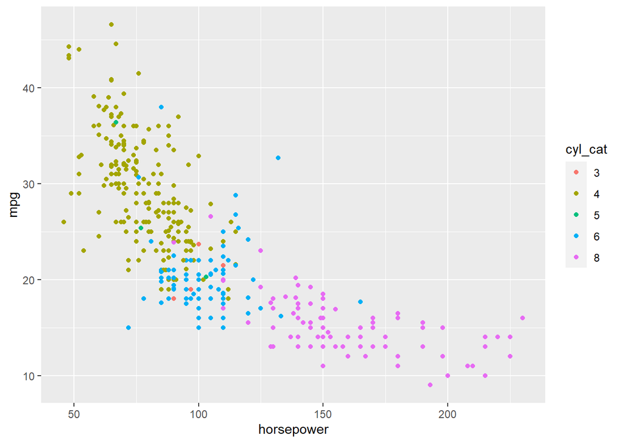

```r
ggplot(df, aes(x=horsepower, y=mpg, color=cyl_cat)) + geom_point()
```

### Converting cylinders to categorical ordered type (ordinal variable)

```r
df = df %>% mutate(cylinders = factor(cylinders, levels = c(3, 4, 5, 6, 8), ordered=TRUE))

df$cylinders
```

```
##   [1] 8 8 8 8 8 8 8 8 8 8 8 8 8 8 4 6 6 6 4 4 4 4 4 4 6 8 8 8 8 4 4 4 4 6 6 6 6
##  [38] 6 8 8 8 8 8 8 8 6 4 6 6 4 4 4 4 4 4 4 4 4 4 4 4 4 8 8 8 8 8 8 8 8 8 3 8 8
##  [75] 8 8 4 4 4 4 4 4 4 4 4 8 8 8 8 8 8 8 8 8 8 8 8 6 6 6 6 6 4 8 8 8 8 6 4 4 4
## [112] 3 4 6 4 8 8 4 4 4 4 8 4 6 8 6 6 6 6 4 4 4 4 6 6 6 8 8 8 8 8 4 4 4 4 4 4 4
## [149] 4 4 4 4 6 6 6 6 8 8 8 8 6 6 6 6 6 8 8 4 4 6 4 4 4 4 6 4 6 4 4 4 4 4 4 4 4
## [186] 4 4 8 8 8 8 6 6 6 6 4 4 4 4 6 6 6 6 4 4 4 4 4 8 4 6 6 8 8 8 8 4 4 4 4 4 8
## [223] 8 8 8 6 6 6 6 8 8 8 8 4 4 4 4 4 4 4 4 6 4 3 4 4 4 4 4 8 8 8 6 6 6 4 6 6 6
## [260] 6 6 6 8 6 8 8 4 4 4 4 4 4 4 4 5 6 4 6 4 4 6 6 4 6 6 8 8 8 8 8 8 8 8 4 4 4
## [297] 4 5 8 4 8 4 4 4 4 4 6 6 4 4 4 4 4 4 4 4 6 4 4 4 4 4 4 4 4 4 4 5 4 4 4 4 4
## [334] 6 3 4 4 4 4 4 4 6 4 4 4 4 4 4 4 4 4 4 4 4 4 4 4 4 4 4 6 6 6 6 8 6 6 4 4 4
## [371] 4 4 4 4 4 4 4 4 4 4 4 4 4 4 4 4 6 6 4 6 4 4 4 4 4 4 4 4
## Levels: 3 < 4 < 5 < 6 < 8
```

```r
str(df)
```

```
## tibble [398 × 10] (S3: tbl_df/tbl/data.frame)
##  $ mpg         : num [1:398] 18 15 18 16 17 15 14 14 14 15 ...
##  $ cylinders   : Ord.factor w/ 5 levels "3"<"4"<"5"<"6"<..: 5 5 5 5 5 5 5 5 5 5 ...
##  $ displacement: num [1:398] 307 350 318 304 302 429 454 440 455 390 ...
##  $ horsepower  : num [1:398] 130 165 150 150 140 198 220 215 225 190 ...
##  $ weight      : num [1:398] 3504 3693 3436 3433 3449 ...
##  $ acceleration: num [1:398] 12 11.5 11 12 10.5 10 9 8.5 10 8.5 ...
##  $ model_year  : num [1:398] 70 70 70 70 70 70 70 70 70 70 ...
##  $ origin      : num [1:398] 1 1 1 1 1 1 1 1 1 1 ...
##  $ car_name    : chr [1:398] "chevrolet chevelle malibu" "buick skylark 320" "plymouth satellite" "amc rebel sst" ...
##  $ cyl_cat     : Factor w/ 5 levels "3","4","5","6",..: 5 5 5 5 5 5 5 5 5 5 ...
```

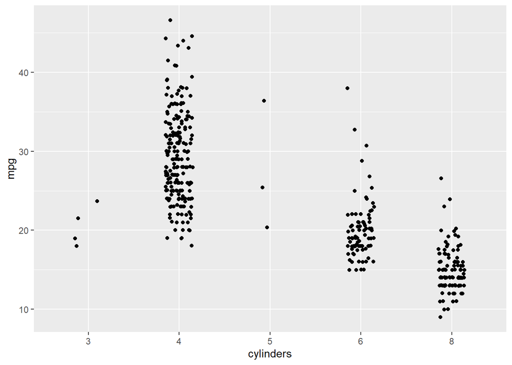

```r
ggplot(df, aes(x=cylinders, y=mpg)) + geom_jitter(width = 0.15)
```

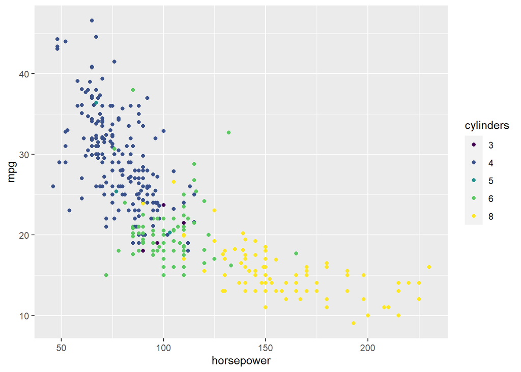

```r
ggplot(df, aes(x=horsepower, y=mpg, color=cylinders)) + geom_point()
```

Scatterplot of mpg vs weight:

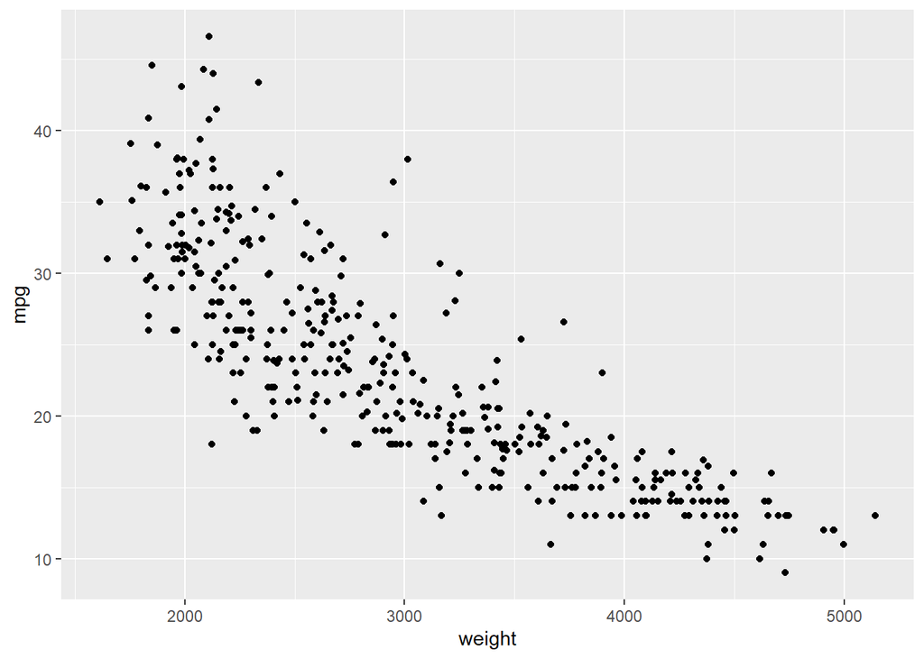

```r
ggplot(df, aes(x=weight, y=mpg)) + geom_point()
```

Scatterplot of mpg vs weight, colored by number of cylinders:

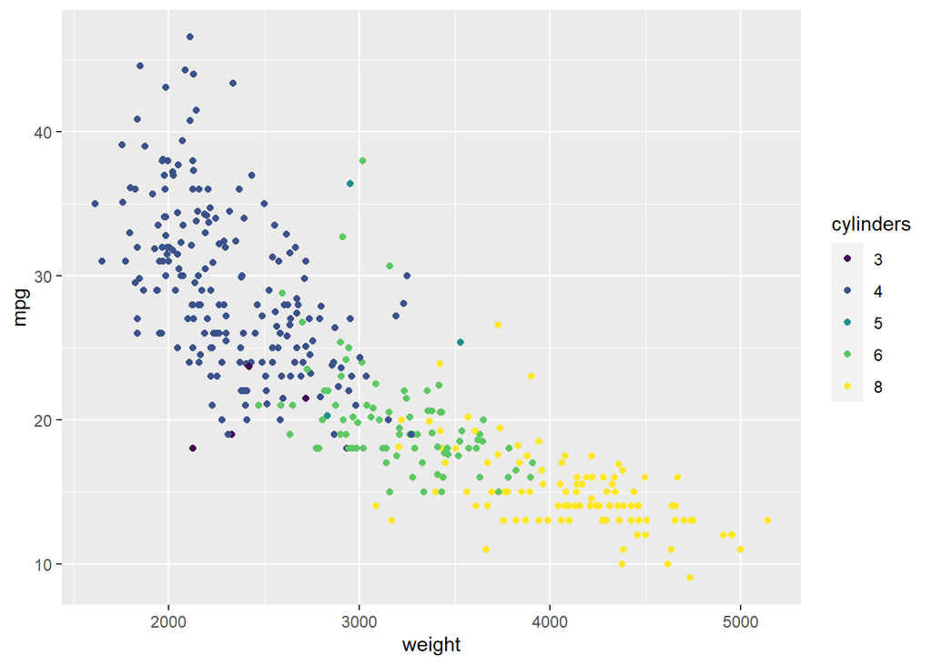

```r
ggplot(df, aes(x=weight, y=mpg, color=cylinders)) + geom_point()
```

The alpha parameter adds transparency to the points:

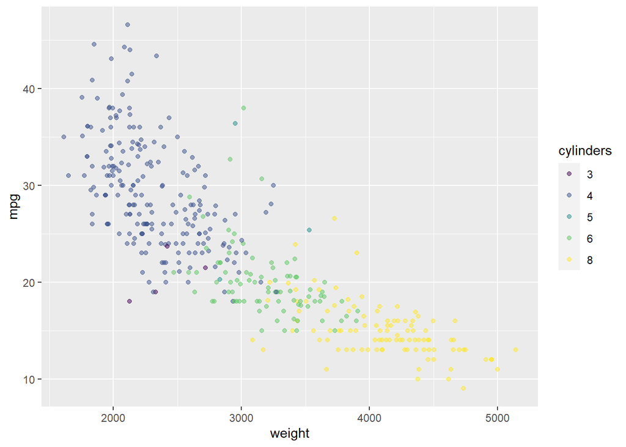

```r
ggplot(df, aes(x=weight, y=mpg, color=cylinders)) + geom_point(alpha=0.5)
```

## Line plot

Line plots are generally useful to visualize time series or sequence data. We need to make sure that the interval between each point is consistent (hourly, daily, monthly, etc.). So, we will calculate the average mpg in each year and create a line plot out of it.

```r
unique(df$model_year)
```

```
##  [1] 70 71 72 73 74 75 76 77 78 79 80 81 82
```

Let’s calculate mean mpg for each year. Hint: Make use of group_by(), summarize()

```r
df_mpg_by_year = df %>%
    group_by(model_year) %>%
    summarize(avg_mpg = mean(mpg)) %>%
    ungroup()
df_mpg_by_year
```

```
## # A tibble: 13 × 2
##    model_year avg_mpg
##         <dbl>   <dbl>
##  1         70    17.7
##  2         71    21.2
##  3         72    18.7
##  4         73    17.1
##  5         74    22.7
##  6         75    20.3
##  7         76    21.6
##  8         77    23.4
##  9         78    24.1
## 10         79    25.1
## 11         80    33.7
## 12         81    30.3
## 13         82    31.7
```

Line plot using base R:

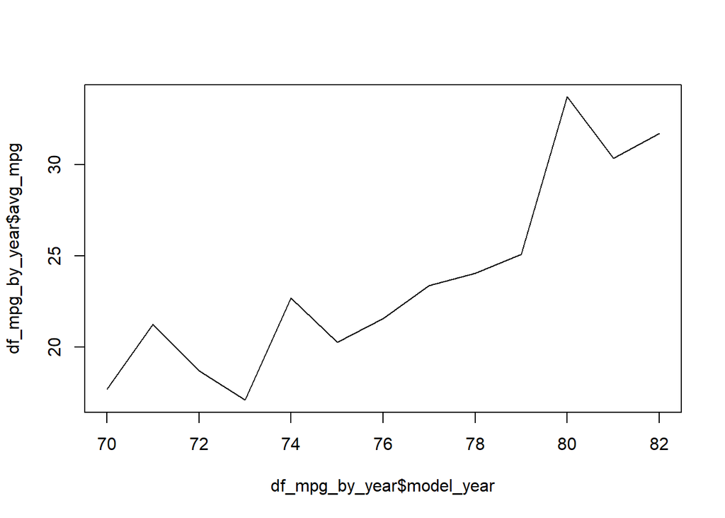

```r
plot(df_mpg_by_year$model_year, df_mpg_by_year$avg_mpg, type='l')
```

Line plot using ggplot:

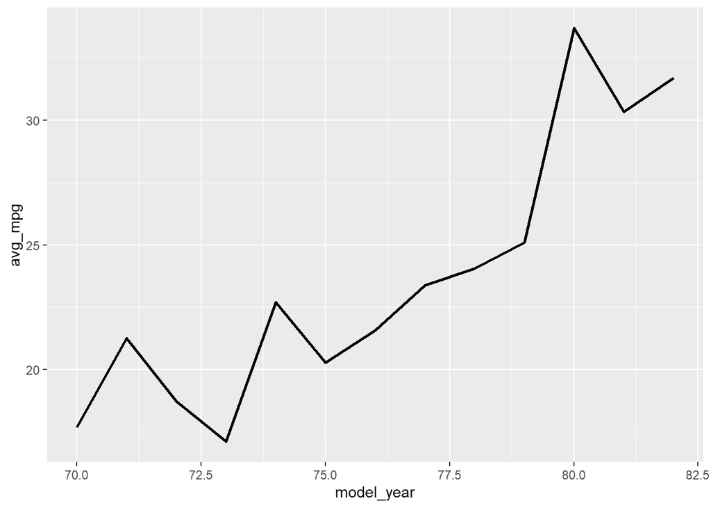

```r
ggplot(df_mpg_by_year, aes(x=model_year, y=avg_mpg)) +
    geom_line(size=1)
```

We can add dots as well to make it more readable:

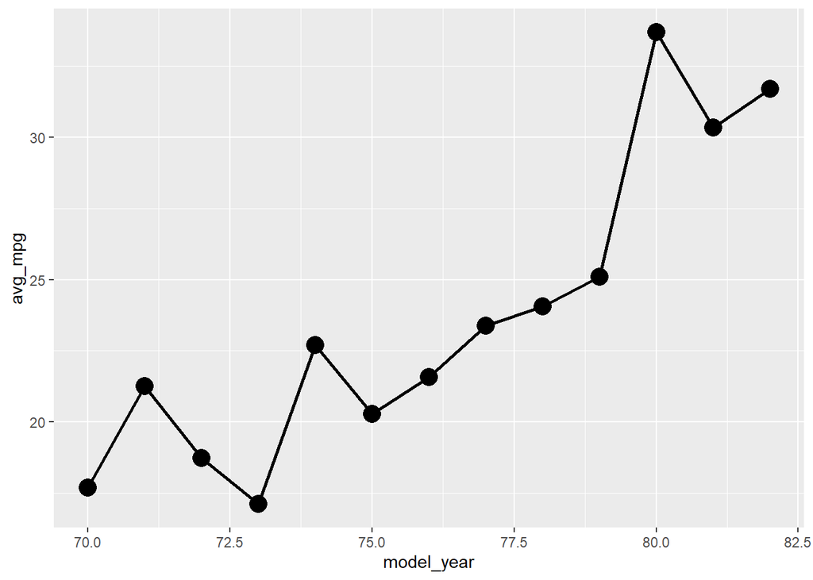

```r
ggplot(df_mpg_by_year, aes(x=model_year, y=avg_mpg)) +
    geom_line(size=1) +
    geom_point(size=5)
```

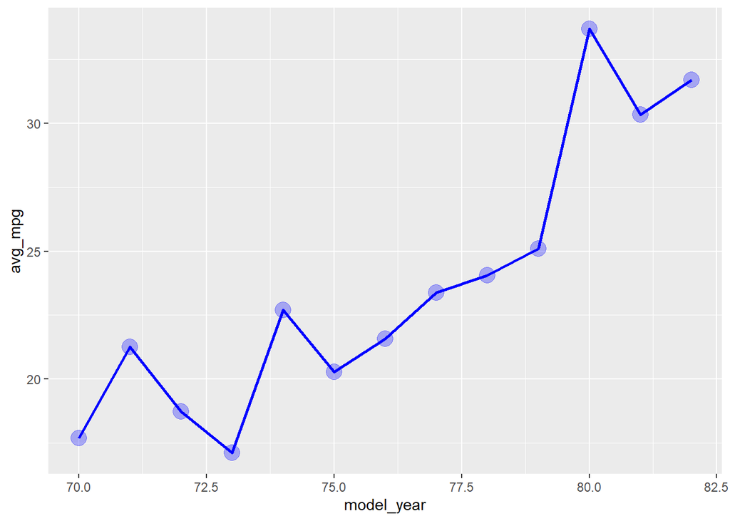

```r
ggplot(df_mpg_by_year, aes(x=model_year, y=avg_mpg)) +
    geom_line(size=1, color='blue') +
    geom_point(size=5, alpha=0.3, color="blue")
```

## Bar plot

Useful to show a numeric value vs a categorical value. For example the count of vehicles in each year, the average mpg of each cylinder type, etc.

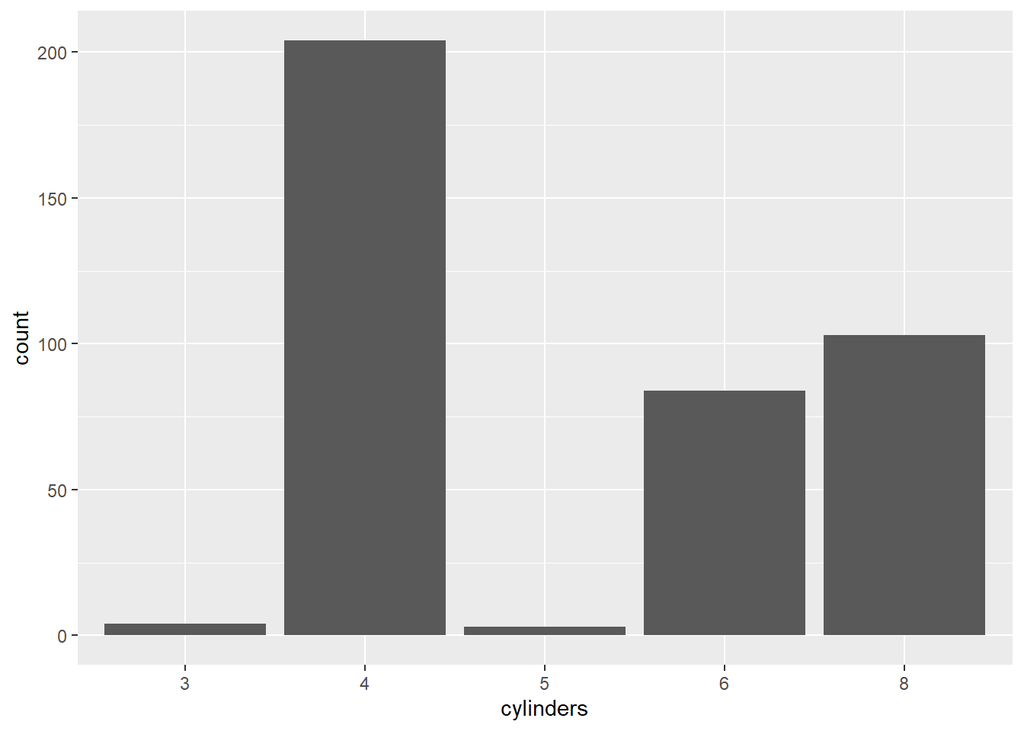

```r
ggplot(df, aes(x=cylinders)) +
    geom_bar()
```

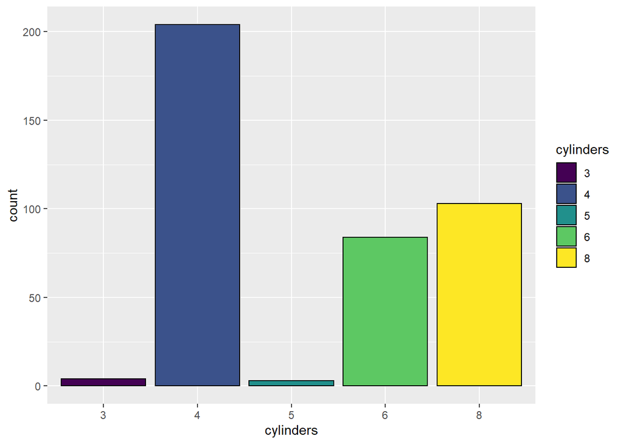

```r
ggplot(df, aes(x=cylinders, fill=cylinders)) +
    geom_bar(color="black")
```

How many vehicles are present in each year?

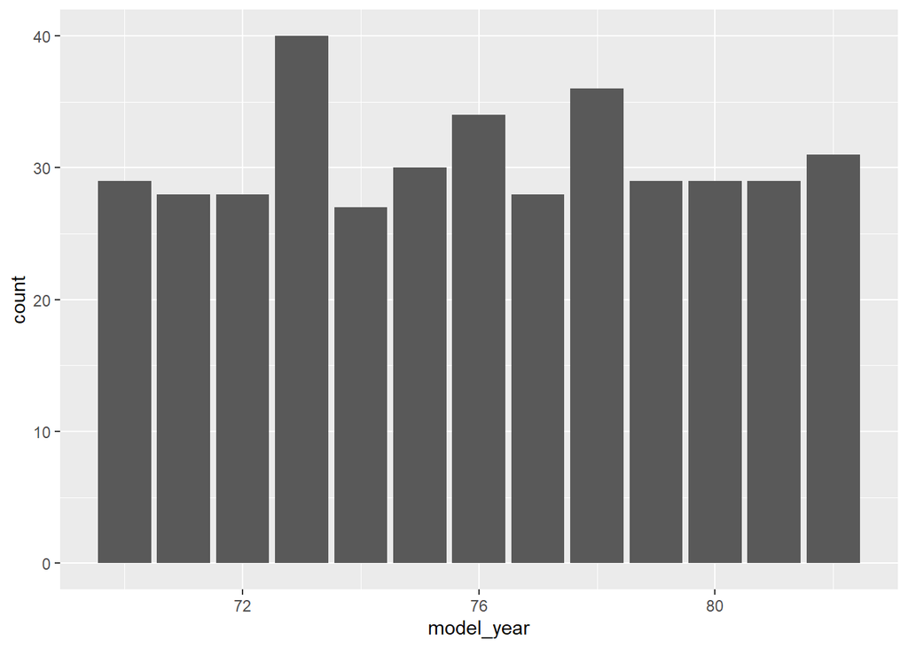

```r
ggplot(df, aes(x=model_year)) +
    geom_bar()
```

Count the number of vehicles from each year and plot it using geom_col():

```r
df_summary = df %>%
    group_by(model_year) %>%
    summarize(N = n(), avg_mpg = mean(mpg))
df_summary
```

```
## # A tibble: 13 × 3
##    model_year     N avg_mpg
##         <dbl> <int>   <dbl>
##  1         70    29    17.7
##  2         71    28    21.2
##  3         72    28    18.7
##  4         73    40    17.1
##  5         74    27    22.7
##  6         75    30    20.3
##  7         76    34    21.6
##  8         77    28    23.4
##  9         78    36    24.1
## 10         79    29    25.1
## 11         80    29    33.7
## 12         81    29    30.3
## 13         82    31    31.7
```

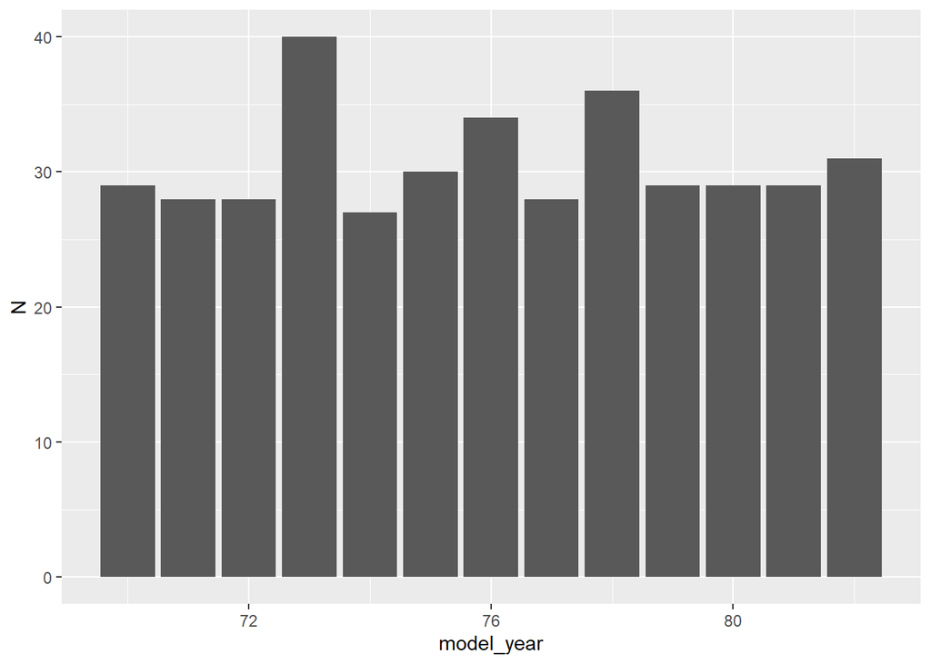

```r
df_summary %>%
    ggplot(aes(x=model_year, y=N)) +
    geom_col()
```

To create bar plot using base R you need to have the summarized data ready.

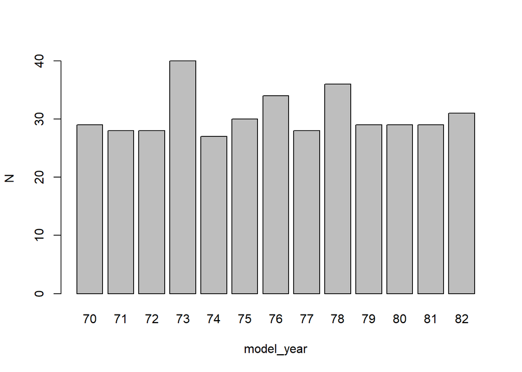

```r
barplot(N ~ model_year, data=df_summary)
```

Count the number of vehicles in each year to create a bar plot colored by cylinders:

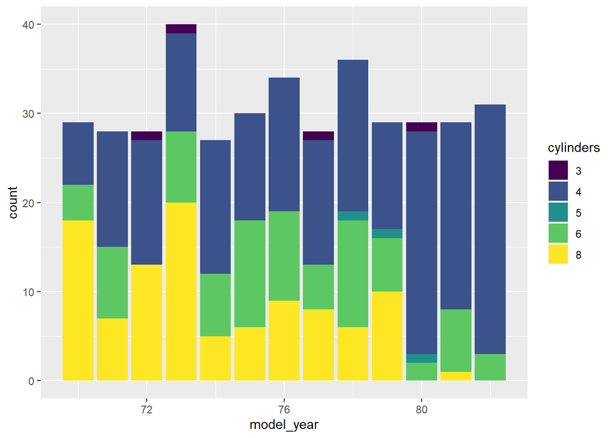

```r
df %>%
    ggplot(aes(x=model_year, fill=cylinders)) +
    geom_bar()
```

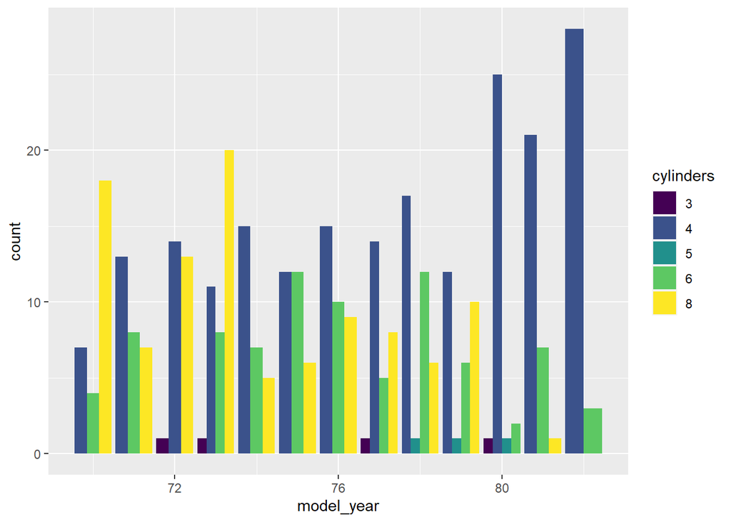

```r
df %>%
    ggplot(aes(x=model_year, fill=cylinders)) +
    geom_bar(position = "dodge")
```

## Histograms

```r
str(df)
```

```
## tibble [398 × 10] (S3: tbl_df/tbl/data.frame)
##  $ mpg         : num [1:398] 18 15 18 16 17 15 14 14 14 15 ...
##  $ cylinders   : Ord.factor w/ 5 levels "3"<"4"<"5"<"6"<..: 5 5 5 5 5 5 5 5 5 5 ...
##  $ displacement: num [1:398] 307 350 318 304 302 429 454 440 455 390 ...
##  $ horsepower  : num [1:398] 130 165 150 150 140 198 220 215 225 190 ...
##  $ weight      : num [1:398] 3504 3693 3436 3433 3449 ...
##  $ acceleration: num [1:398] 12 11.5 11 12 10.5 10 9 8.5 10 8.5 ...
##  $ model_year  : num [1:398] 70 70 70 70 70 70 70 70 70 70 ...
##  $ origin      : num [1:398] 1 1 1 1 1 1 1 1 1 1 ...
##  $ car_name    : chr [1:398] "chevrolet chevelle malibu" "buick skylark 320" "plymouth satellite" "amc rebel sst" ...
##  $ cyl_cat     : Factor w/ 5 levels "3","4","5","6",..: 5 5 5 5 5 5 5 5 5 5 ...
```

Histogram of mpg using base R:

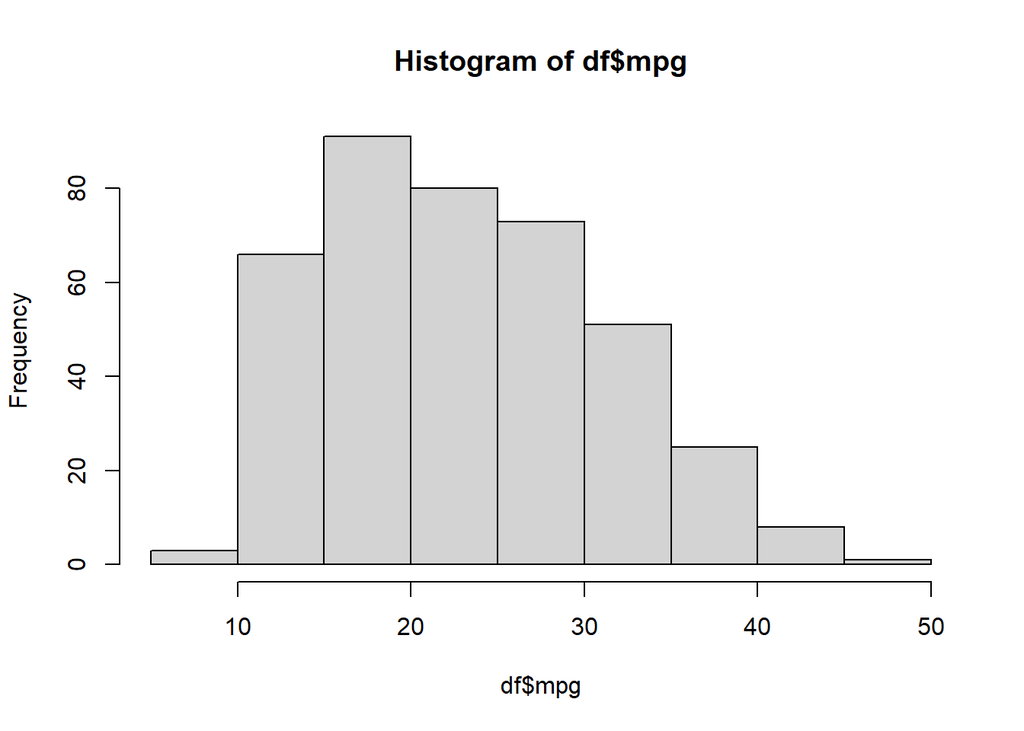

```r
hist(df$mpg)
```

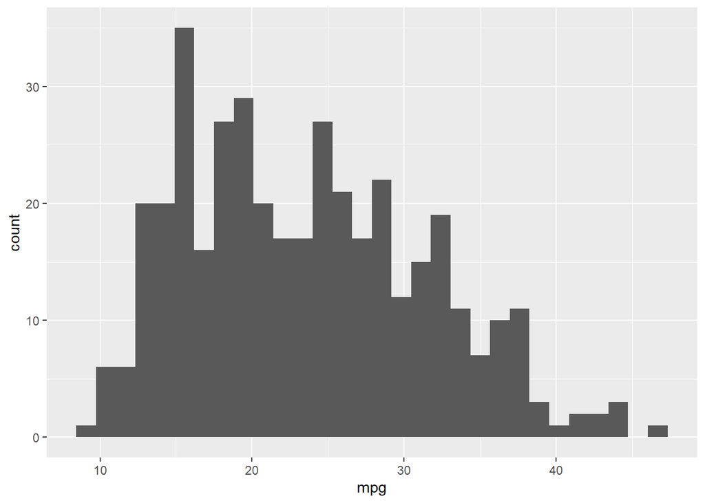

```r
ggplot(df, aes(x=mpg)) + geom_histogram()
```

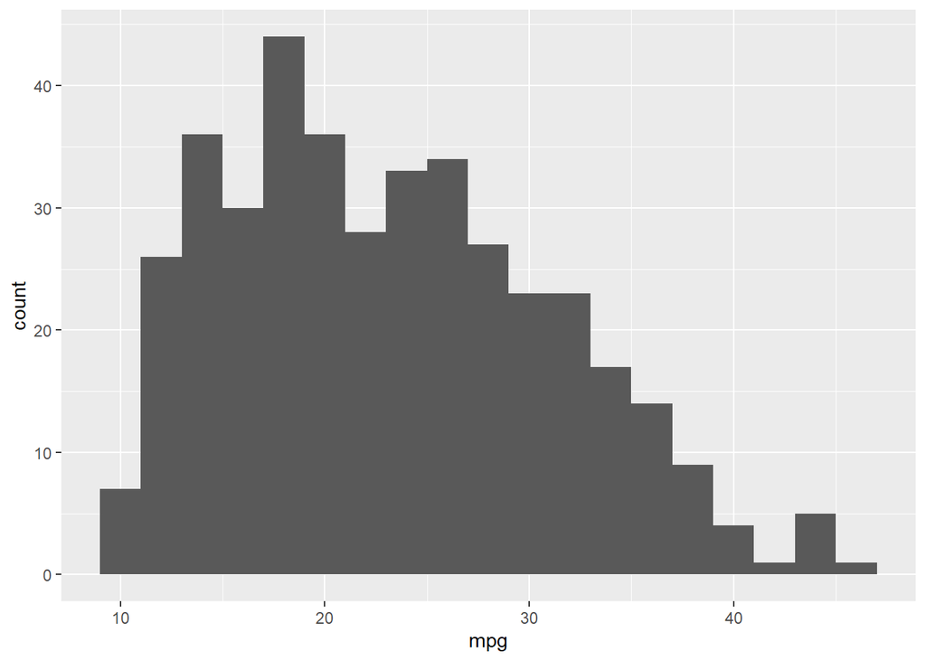

```r
ggplot(df, aes(x=mpg)) + geom_histogram(binwidth = 2)
```

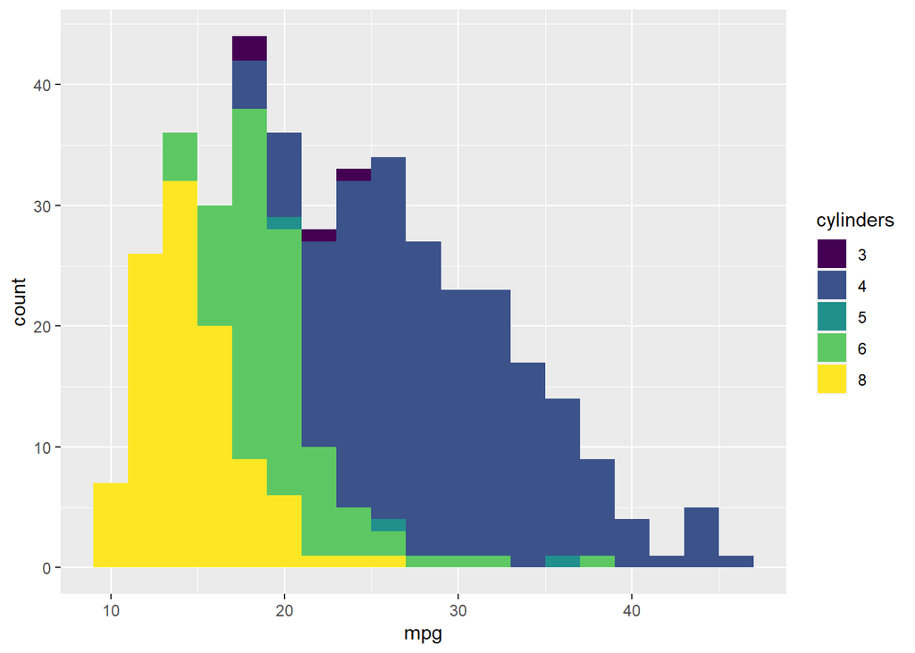

```r
ggplot(df, aes(x=mpg, fill=cylinders)) + geom_histogram(binwidth = 2, position= "stack")
```

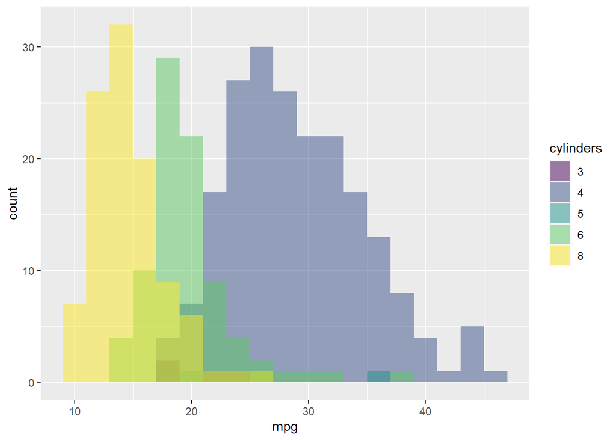

```r
ggplot(df, aes(x=mpg, fill=cylinders)) + geom_histogram(binwidth = 2, position= "identity", alpha =0.5)
```